# Spatial Modeling of Residential Property Values in Chicago

This project develops a tract-level home value modeling framework for the City of Chicago using structural housing characteristics, spatial features, and neighborhood-level indicators. I use tract-level modeling rather than parcel-level modeling because it allows the analysis to capture systematic spatial variation in home values that may be obscured by noise in individual property data. Census tracts are intended to represent relatively homogeneous neighborhoods, making them an appropriate unit of analysis for examining how location and surrounding context influence housing values.

### Gathering variables

```
Total tracts from Census: 1332
Raw value range: $-666,666,666 to $1,685,400
Tracts with error codes: 26
Tracts removed: 26
Clean tracts remaining: 1306
Clean value range: $25,100 to $1,685,400
```

### Spatial Join and Preparation

```
Homes with tract assignment: 437999
```

### Spatial features

I focused on incorporating spatial features that I believe are highly relevant to understanding the characteristics and context of homes in Chicago. I chose these features based on their potential impact on residential desirability, accessibility, and safety.

To measure how close homes are to transit (L-stops and bus stations) and schools, I used a BallTree nearest-neighbor search. Unlike a simple Euclidean distance distance calculation that checks every home against every point of interest, which can be very slow for large datasets, the BallTree organizes locations into a tree structure that makes searching much faster. This method lets me efficiently calculate distances for hundreds of thousands of homes against thousands of transit stops or schools, while still keeping the results accurate enough for detailed neighborhood-level analysis.

### Aggregate home data to tract level

```
Aggregated 781 tracts with 26 features
```

### Merge with cleaned census target

```
Final tract dataset: 766 tracts
```

### Feature engineering

I engineered features to capture how multiple factors interact to determine property value. I normalized extremes by log-transforming crime data and converting distances into inverse proximity scores, emphasizing low-crime areas and walkable access. I created interaction features, such as School Safety Scores (school ratings × local crime) and Transit Utility (Loop access × station proximity), to reflect real-world decision-making. Structural metrics like lot coverage, weighted bathroom count, and bedroom ratios describe usable space and building efficiency. Finally, I grouped building ages into five categories to capture market-relevant stages of aging and renovation. These transformations turn raw data into a multi-dimensional view of Chicago real estate, giving the model the contextual intelligence needed to understand the trade-offs and synergies that drive property values.

```
Total features: 41
```

### Target variable distribution

```
Median_home_value statistics:
  Min: $71,200
  Max: $1,393,400
  Mean: $351,551
  Std: $187,292
  Null values: 0
  Zero/negative values: 0
Clean tract dataset: 766 tracts

Categorical features (11): ['ext_wall_mode', 'roof_mat_mode', 'basement_mode', 'heat_type_mode', 'ac_installed_mode', 'family_type_mode', 'ohare_noise_mode', 'flood_factor_mode', 'near_road_100_mode', 'near_road_300_mode', 'age_category']
Numeric features (28): 28 total
  Warning: garage_size_mean is entirely NaN. Filling with 0.

Feature matrix shape: (766, 39)
Number of features: 39
Target variable range: $71,200 - $1,393,400
```

### Data leakage diagnostic

I had to remove the variable median_household_income to be conservative about endogeneity, but I understand it is a demographic driver.

```
1 features may contain target information:
  - family_value_score

Top correlations with target:
median_home_value             1.000000
lot_coverage                  0.499408
fireplaces_mean               0.488487
dist_to_loop_ft_mean          0.471931
total_baths                   0.467159
ac_installed_mode             0.460849
full_baths_mean               0.440581
school_access_score           0.401111
nearest_school_rating_mean    0.396079
half_baths_mean               0.380381
Name: median_home_value, dtype: float64

Final feature count after leakage check: 38
```

### K-fold cross-validation

```
CV RMSE (original scale): Mean 96,972.33, Std 8,439.85
```

Implemented 5-fold CV to ensure model generalizes across Chicago tracts, reducing overfitting for reliable valuations.

## Training XGboost model

I chose XGBoost because it effectively captures the complex, non-linear dynamics of Chicago’s housing market. It is robust to outliers and missing data, learning from difficult cases without being skewed by anomalies. XGBoost also manages correlated features, like bedrooms and bathrooms, without destabilizing predictions. Built-in regularization prevents overfitting, ensuring the model generalizes well across the city. Finally, I can interpret its decisions using Feature Importance scores, showing which factors, such as transit access, school quality, or lot size, most influence property value. Overall, XGBoost balances predictive power, robustness, and interpretability, making it well-suited for modeling the nuanced patterns of urban real estate.

```
Fitting 5 folds for each of 50 candidates, totalling 250 fits

Best Params: {'colsample_bytree': np.float64(0.7794836405757274), 'learning_rate': np.float64(0.022508475721215296), 'max_depth': 4, 'n_estimators': 885, 'reg_alpha': np.float64(0.43436355527446946), 'reg_lambda': np.float64(0.10338634985686546), 'subsample': np.float64(0.6132681744295425)}
```

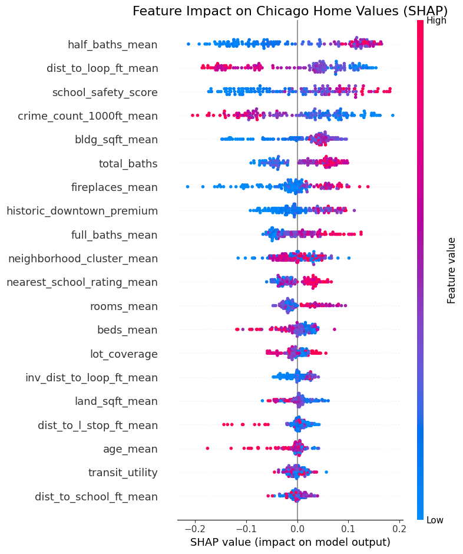

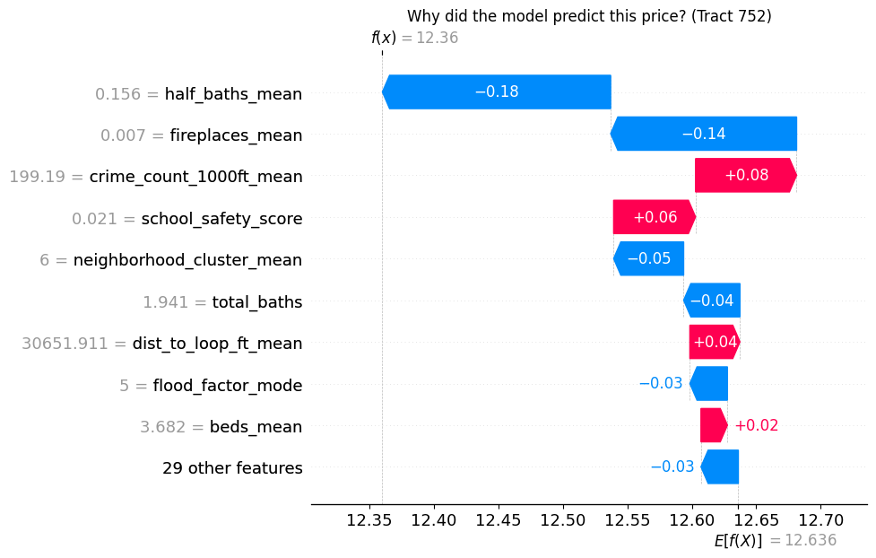

To validate the model's internal logic, a SHAP (SHapley Additive exPlanations) summary plot was used to examine feature importance and directionality. Unlike standard feature importance, which only shows how much a variable matters, this plot illustrates how it affects the price.

## Predictions and error analysis

```
Error analysis by price segment:
               Count  Avg_Value  Avg_%_Error  Std_%_Error  Avg_$_Error  \
price_segment
Very Low         154  159474.68         6.07        16.61      8899.47
Low              153  234100.65         1.66        12.29      3740.40
Medium           153  301834.64        -0.91         7.08     -2811.05
High             153  407797.39        -0.51        11.12     -2453.68
Very High        153  655800.65        -4.21        10.18    -28612.72

               Std_$_Error
price_segment
Very Low          25980.17
Low               29067.03
Medium            21338.56
High              45612.02
Very High         67733.63
```

## Investment opportunity analysis

```
Investment profile distribution:
investment_profile
Fairly Valued                  629
Significantly Overvalued        53
High Conviction Opportunity     39
Mildly Overvalued               17
Mild Opportunity                13
Insufficient Data                9
Moderate Opportunity             6
Name: count, dtype: int64
```

The investment profile distribution shows that most census tracts (629) are fairly valued, meaning market prices largely align with the model’s estimated fundamentals. A smaller group of tracts is classified as overvalued, with 53 significantly and 17 mildly overvalued, suggesting prices that exceed model-based expectations and may carry higher risk. On the other hand, 39 tracts are identified as high-conviction opportunities, where predicted values are substantially above current prices, indicating potential undervaluation. Fewer tracts fall into moderate (6) or mild opportunity (13) categories, reflecting weaker but still positive signals, while 9 tracts lack sufficient data for reliable classification.

```
 Predictions exported to: Chicago_Tract_Level_Predictions_Clean.csv
 GIS map exported to: Chicago_Tract_Values_Map_Clean.geojson
 Feature importance exported to: Chicago_Tract_Feature_Importance_Clean.csv
Investment opportunities exported to: Chicago_Investment_Opportunities.csv
```

## Summary

```
Model Summary:
 Investment opportunities: 58 tracts identified
R² Score: 0.7714
MAE: $69,533
RMSE: $96,556
MAPE: 20.3%
 86.9% of tracts within 10% of actual value
 92.2% of tracts within 20% of actual value
```

The model demonstrates strong predictive performance with an R² of 0.771, explaining about 77% of the variation in Chicago home values. On average, predictions are off by $69,533 (20.3%), and the majority of census tracts are accurately estimated, with 86.9% within 10% and 92.2% within 20% of actual values. The most influential feature is the total number of baths. Using the model, I identified 58 tracts with strong investment potential, providing actionable insights for targeted real estate opportunities across the city.

## Visuals

#### Feature Importance Plot

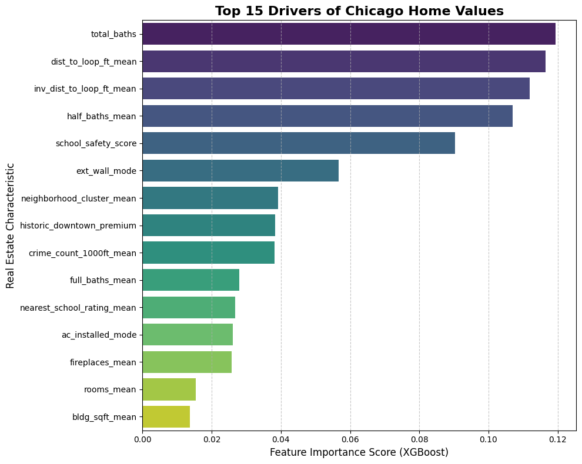

#### Actual Vs. Predicted

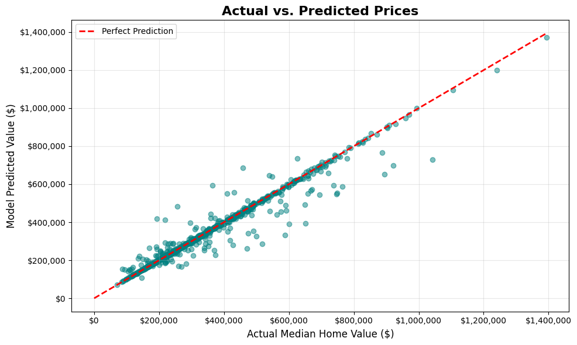

#### Tract valuation map

Make this Notebook Trusted to load map: File -> Trust Notebook

[interactive chart not shown]